# Regression Diagnostics with R

Anne Boomsma (April 30, 2014)

Reviewed by Francesc Carmona (April 21, 2023)

# 1 Introduction

Load the `faraway` package, and from that package data frame `savings`.

```r
library(faraway)
data(savings)
```

Linear regression model M1

```r
M1 <- lm(sr ~ pop15 + pop75 + dpi + ddpi, data=savings)
(M1_sum <- summary(M1))    # summary of estimated model
```

```
##
## Call:
## lm(formula = sr ~ pop15 + pop75 + dpi + ddpi, data = savings)
##
## Residuals:
##     Min      1Q  Median      3Q     Max
## -8.2422 -2.6857 -0.2488  2.4280  9.7509
##
## Coefficients:
##               Estimate Std. Error t value Pr(>|t|)
## (Intercept) 28.5660865  7.3545161   3.884 0.000334 ***
## pop15       -0.4611931  0.1446422  -3.189 0.002603 **
## pop75       -1.6914977  1.0835989  -1.561 0.125530
## dpi         -0.0003369  0.0009311  -0.362 0.719173
## ddpi         0.4096949  0.1961971   2.088 0.042471 *
## ---
## Signif. codes:  0 '***' 0.001 '**' 0.01 '*' 0.05 '.' 0.1 ' ' 1
##
## Residual standard error: 3.803 on 45 degrees of freedom
## Multiple R-squared:  0.3385, Adjusted R-squared:  0.2797
## F-statistic: 5.756 on 4 and 45 DF,  p-value: 0.0007904
```

Check whether the details of this summary are well understood.

```r
options(show.signif.stars=F) # suppress stars of significance
options(digits=4)            # set numbers of significant digits
```

The fitted values $\hat{Y}_i$ and the residuals $e_i$ can be obtained as follows:

```r
fitted(M1)                    # predicted Y_i
```

```
##      Australia        Austria        Belgium        Bolivia         Brazil
##         10.566         11.454         10.951          6.448          9.327
##         Canada          Chile          China       Colombia     Costa Rica
##          9.107          8.842          9.364          6.432          5.655
##        Denmark        Ecuador        Finland         France        Germany
##         11.450          5.996         12.921         10.165         12.731
##         Greece      Guatamala       Honduras        Iceland          India
##         13.786          6.365          6.990          7.481          8.491
##        Ireland          Italy          Japan          Korea     Luxembourg
##          7.949         12.353         15.819         10.087         12.021
##          Malta         Norway    Netherlands    New Zealand      Nicaragua
##         12.505         11.122         14.224          8.384          6.654
##         Panama       Paraguay           Peru    Philippines       Portugal
##          7.734          8.146          6.161          6.105         13.258
##   South Africa South Rhodesia          Spain         Sweden    Switzerland
##         10.657         12.009         12.441         11.120         11.643
##         Turkey        Tunisia United Kingdom  United States      Venezuela
##          7.796          5.628         10.502          8.672          5.587
##         Zambia        Jamaica        Uruguay          Libya       Malaysia
##          8.809         10.739         11.504         11.720          7.681
```

```r
residuals(M1)                 # residuals e_i
```

```
##      Australia        Austria        Belgium        Bolivia         Brazil
##         0.8636         0.6164         2.2190        -0.6983         3.5528
##         Canada          Chile          China       Colombia     Costa Rica
##        -0.3169        -8.2422         2.5360        -1.4517         5.1251
##        Denmark        Ecuador        Finland         France        Germany
##         5.4002        -2.4056        -1.6811         2.4755        -0.1807
##         Greece      Guatamala       Honduras        Iceland          India
##        -3.1162        -3.3553         0.7100        -6.2106         0.5087
##        Ireland          Italy          Japan          Korea     Luxembourg
##         3.3911         1.9268         5.2815        -6.1070        -1.6708
##          Malta         Norway    Netherlands    New Zealand      Nicaragua
##         2.9749        -0.8718         0.4255         2.2856         0.6464
##         Panama       Paraguay           Peru    Philippines       Portugal
##        -3.2942        -6.1258         6.5394         6.6750        -0.7684
##   South Africa South Rhodesia          Spain         Sweden    Switzerland
##         0.4832         1.2914        -0.6712        -4.2603         2.4868
##         Turkey        Tunisia United Kingdom  United States      Venezuela
##        -2.6657        -2.8179        -2.6924        -1.1116         3.6325
##         Zambia        Jamaica        Uruguay          Libya       Malaysia
##         9.7509        -3.0185        -2.2638        -2.8295        -2.9709
```

```r
which.max(abs(residuals(M1))) # largest absolute residual |e_i|?
```

```
## Zambia
##     46
```

Graphic overview with the `plot()` function on an `lm` object.

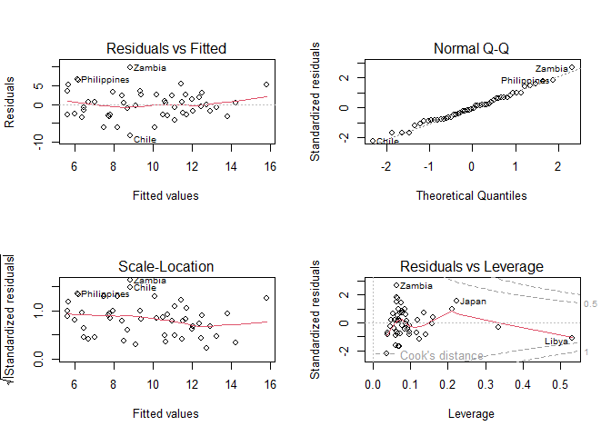

```r
oldpar <- par(mfrow=c(2,2))
plot(M1)
```

```r
par(oldpar)
```

The same graphic with the `gglm` package

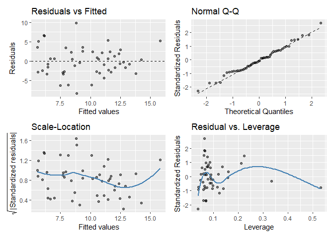

```r
library(gglm)
gglm(M1)
```

What are these plots for? We will see it in the following sections.

# 2 Checking model assumptions

## 2.1 Constant variance

**Residual plot: $\hat{Y}_i$ against $e_i$**

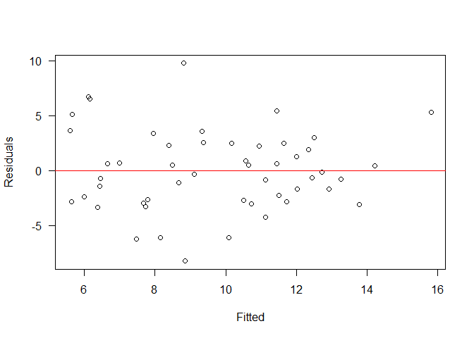

```r
par(las=1)               # horizontal style of axis labels
plot(fitted(M1), residuals(M1), xlab="Fitted", ylab="Residuals")
abline(h=0, col="red")   # draws a horizontal red line at y = 0
```

Diagnostic plot for an `lm()`.

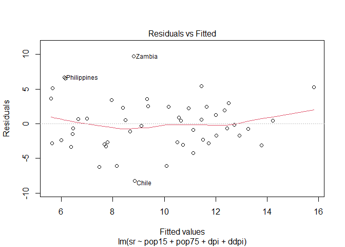

```r
plot(M1, which=1)
```

Another graphic with the `gglm` package

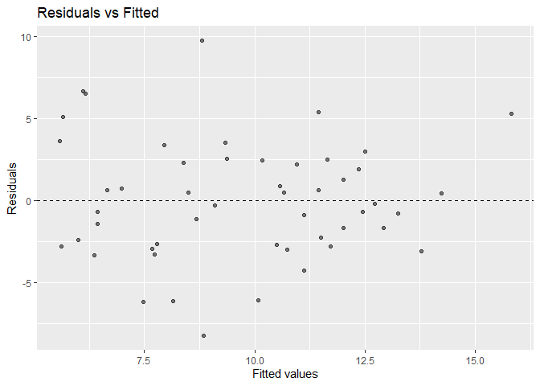

```r
ggplot2::ggplot(data = M1) + stat_fitted_resid()
```

**Absolute residual plot: $\hat{Y}_i$ against $|e_i|$**

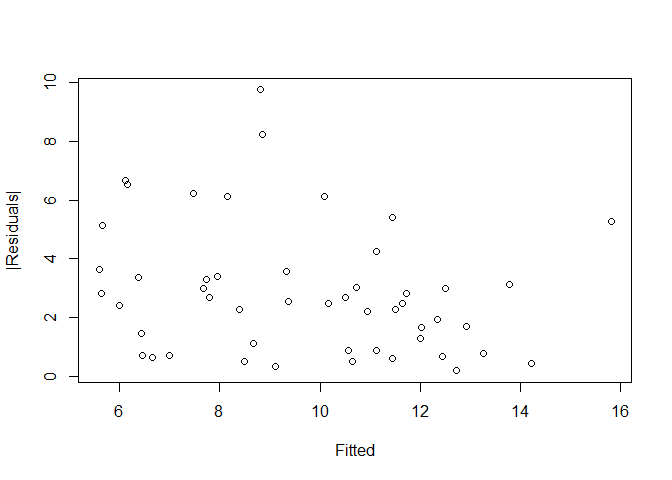

```r
plot(fitted(M1), abs(residuals(M1)), xlab="Fitted", ylab="|Residuals|")
```

**Absolute residual plot: $\hat{Y}_i$ against sqrt(standardized $|e_i|$)**

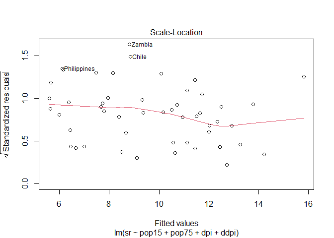

```r
plot(M1, which=3)
```

With the `gglm` package

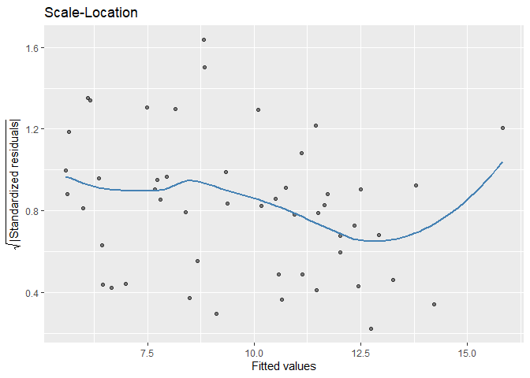

```r
ggplot2::ggplot(data = M1) + stat_scale_location()
```

**Quick and dirty test (Faraway)**

```r
summary(lm(abs(residuals(M1)) ~ fitted(M1)))
```

```
##
## Call:
## lm(formula = abs(residuals(M1)) ~ fitted(M1))
##
## Residuals:
##    Min     1Q Median     3Q    Max
## -2.840 -1.608 -0.349  0.662  6.704
##
## Coefficients:
##             Estimate Std. Error t value Pr(>|t|)
## (Intercept)    4.840      1.186    4.08  0.00017
## fitted(M1)    -0.203      0.119   -1.72  0.09250
##
## Residual standard error: 2.16 on 48 degrees of freedom
## Multiple R-squared:  0.0578, Adjusted R-squared:  0.0382
## F-statistic: 2.95 on 1 and 48 DF,  p-value: 0.0925
```

**Interpretation of residual plots**

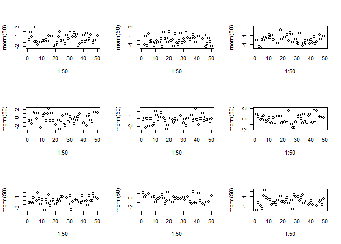

```r
par(mfrow=c(3,3))
for(i in 1:9) plot(1:50,rnorm(50))              # constant variance
```

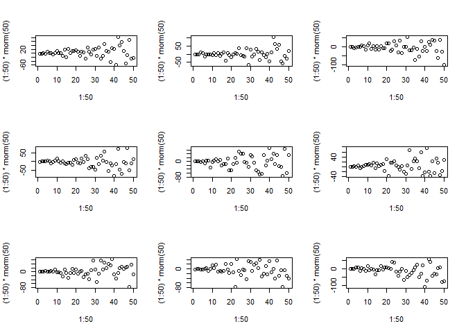

```r
for(i in 1:9) plot(1:50,(1:50)*rnorm(50))       # strong heterogeneity
```

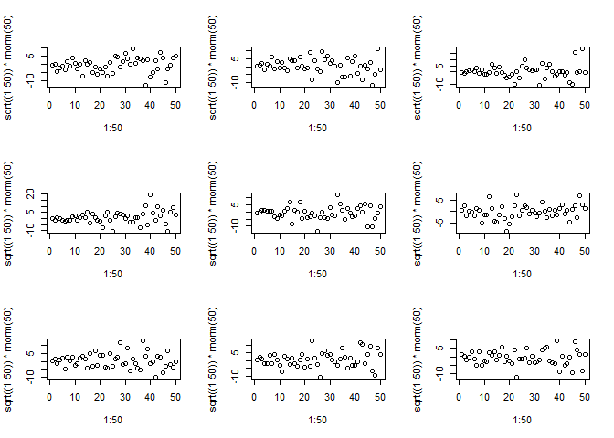

```r
for(i in 1:9) plot(1:50,sqrt((1:50))*rnorm(50)) # mild heterogeneity
```

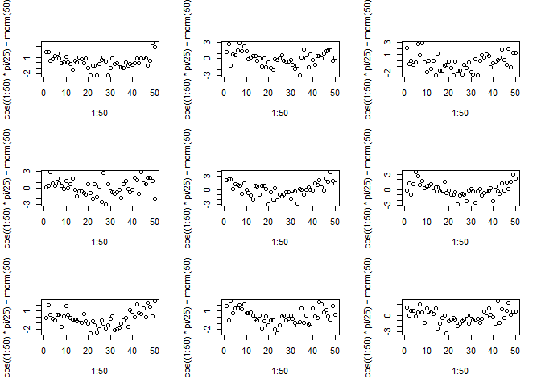

```r
for(i in 1:9) plot(1:50,cos((1:50)*pi/25)+rnorm(50)) # non-linearity
```

## 2.2 Normality

**Q-Q plots**

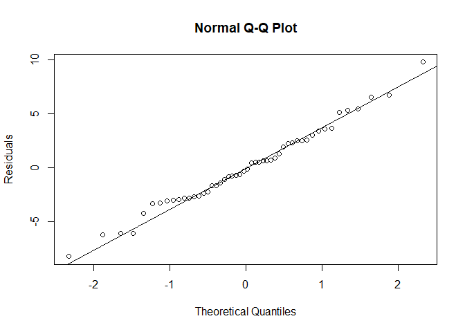

```r
par(mfrow=c(1,1))                       # reset plotting device
qqnorm(residuals(M1), ylab="Residuals") # Q-Q plot
qqline(residuals(M1))                   # line through Q1 and Q3
```

With the `gglm` package

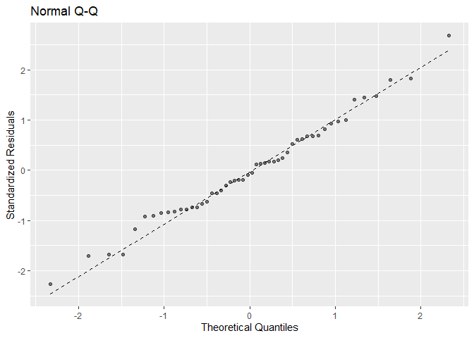

```r
ggplot2::ggplot(data = M1) + stat_normal_qq()
```

**Interpretation of Q-Q plots**

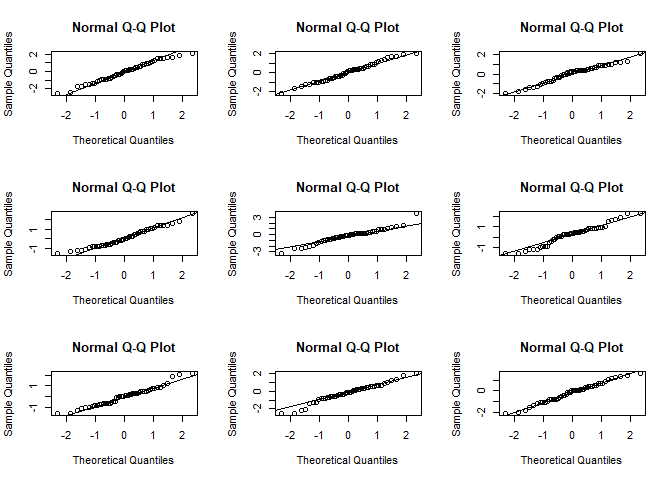

```r
par(mfrow=c(3,3))
# standard normal distribution (symmetric)
for(i in 1:9) {x = rnorm(50); qqnorm(x); qqline(x)}
```

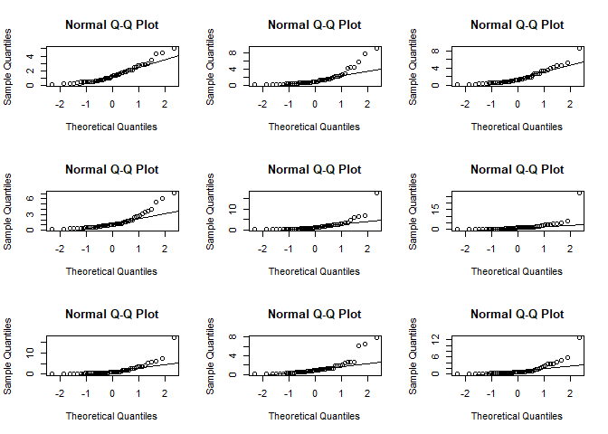

```r
# lognormal distribution (long right tail, skew to right)
for(i in 1:9) {x = rlnorm(50); qqnorm(x); qqline(x)}
```

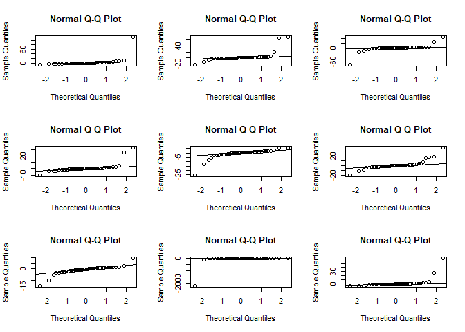

```r
# Student t-distribution with one df (heavy tails, platykurtic)
for(i in 1:9) {x = rt(50,1); qqnorm(x); qqline(x)}
```

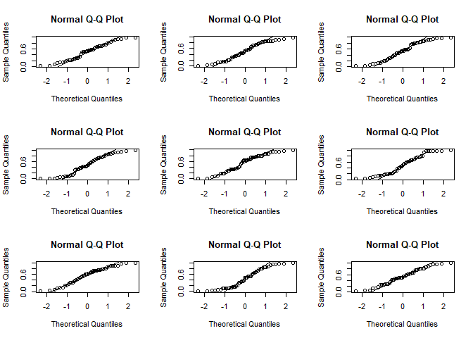

```r
# uniform (0,1) distribution (short tails, leptokurtic)
for(i in 1:9) {x = runif(50); qqnorm(x); qqline(x)}
```

**Histograms and box plots**

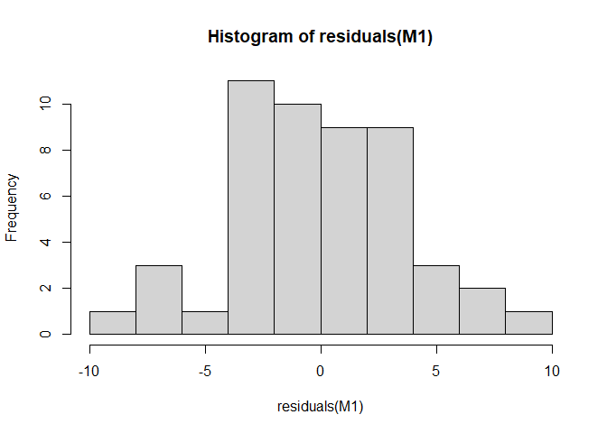

```r
par(mfrow=c(1,1))
hist(residuals(M1))
```

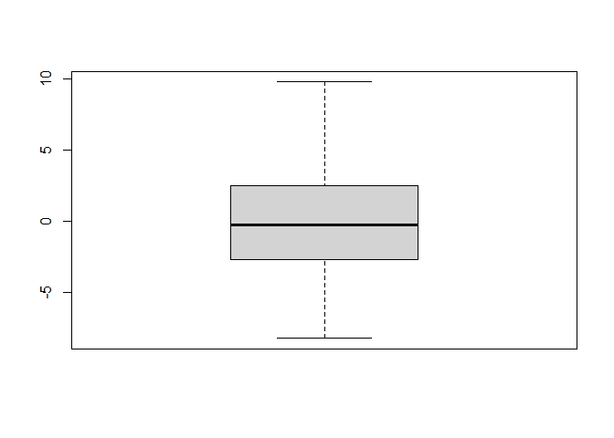

```r
boxplot(residuals(M1))
```

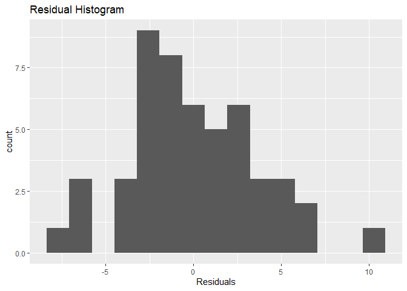

```r
ggplot2::ggplot(data = M1) + stat_resid_hist(bins=15)
```

**Shapiro-Wilk normality test**

```r
shapiro.test(residuals(M1))
```

```
##
##  Shapiro-Wilk normality test
##
## data:  residuals(M1)
## W = 0.99, p-value = 0.9
```

## 2.3 Independent errors

The data set `airquality` from the `datasets` package serves as a more appropriate illustration here than the `savings` data.

```r
attach(airquality)
str(airquality)
```

```
## 'data.frame':    153 obs. of  6 variables:
##  $ Ozone  : int  41 36 12 18 NA 28 23 19 8 NA ...
##  $ Solar.R: int  190 118 149 313 NA NA 299 99 19 194 ...
##  $ Wind   : num  7.4 8 12.6 11.5 14.3 14.9 8.6 13.8 20.1 8.6 ...
##  $ Temp   : int  67 72 74 62 56 66 65 59 61 69 ...
##  $ Month  : int  5 5 5 5 5 5 5 5 5 5 ...
##  $ Day    : int  1 2 3 4 5 6 7 8 9 10 ...
```

**Scatter plots**

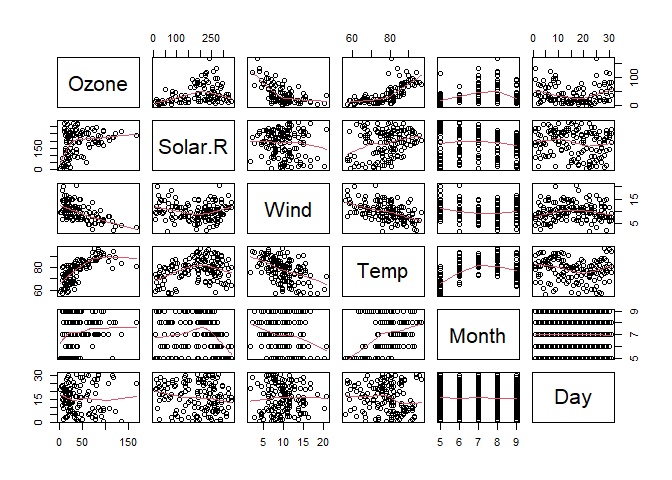

```r
pairs(airquality, panel=panel.smooth)
```

Inspection of correlations for linear relationships (listwise deletion of missing cases).

```r
round(cor(airquality, use="complete.obs"), digits=2)
```

```
##         Ozone Solar.R  Wind  Temp Month   Day
## Ozone    1.00    0.35 -0.61  0.70  0.14 -0.01
## Solar.R  0.35    1.00 -0.13  0.29 -0.07 -0.06
## Wind    -0.61   -0.13  1.00 -0.50 -0.19  0.05
## Temp     0.70    0.29 -0.50  1.00  0.40 -0.10
## Month    0.14   -0.07 -0.19  0.40  1.00 -0.01
## Day     -0.01   -0.06  0.05 -0.10 -0.01  1.00
```

Next a linear regression model `M2` for `Ozone` is fitted to the data, where `Month` and `Day` are not used as linear predictors.

```r
M2 <- lm(Ozone ~ Solar.R + Wind + Temp, data=airquality,
                na.action=na.exclude)
summary(M2)
```

```
##
## Call:
## lm(formula = Ozone ~ Solar.R + Wind + Temp, data = airquality,
##     na.action = na.exclude)
##
## Residuals:
##    Min     1Q Median     3Q    Max
## -40.48 -14.22  -3.55  10.10  95.62
##
## Coefficients:
##             Estimate Std. Error t value Pr(>|t|)
## (Intercept) -64.3421    23.0547   -2.79   0.0062
## Solar.R       0.0598     0.0232    2.58   0.0112
## Wind         -3.3336     0.6544   -5.09  1.5e-06
## Temp          1.6521     0.2535    6.52  2.4e-09
##
## Residual standard error: 21.2 on 107 degrees of freedom
##   (42 observations deleted due to missingness)
## Multiple R-squared:  0.606,  Adjusted R-squared:  0.595
## F-statistic: 54.8 on 3 and 107 DF,  p-value: <2e-16
```

```r
table(complete.cases(airquality))
```

```
##
## FALSE  TRUE
##    42   111
```

We notice that the data frame has missing values. There are 111 complete cases only. The default with respect to missing values for regression analysis in R is to omit any case that contains a missing value. The option `na.action=na.exclude` does not use cases with missing values in the computation but keeps track of which cases are missing in the residual, fitted values and other quantities.

Residual diagnostics show some non-constant variance and non-linearity –see the previous `pairs()` plots. Therefore, a logarithmic transformation of the response variable `Ozone` is made, resulting in model `M2_log`.

**Transformation of the response variable**

```r
M2_log <- lm(log(Ozone) ~ Solar.R + Wind + Temp, airquality, na.action=na.exclude)
summary(M2_log)
```

```
##
## Call:
## lm(formula = log(Ozone) ~ Solar.R + Wind + Temp, data = airquality,
##     na.action = na.exclude)
##
## Residuals:
##     Min      1Q  Median      3Q     Max
## -2.0619 -0.2997 -0.0023  0.3076  1.2358
##
## Coefficients:
##              Estimate Std. Error t value Pr(>|t|)
## (Intercept) -0.262132   0.553567   -0.47  0.63680
## Solar.R      0.002515   0.000557    4.52  1.6e-05
## Wind        -0.061562   0.015713   -3.92  0.00016
## Temp         0.049171   0.006088    8.08  1.1e-12
##
## Residual standard error: 0.509 on 107 degrees of freedom
##   (42 observations deleted due to missingness)
## Multiple R-squared:  0.664,  Adjusted R-squared:  0.655
## F-statistic: 70.6 on 3 and 107 DF,  p-value: <2e-16
```

Notice the improvement of fit of model `M2_log` over that of model `M2`, where `Ozone` was untransformed.

We now check for correlated error terms. Recall that there is a time component in the airquality data.

**Index plot of residuals $e_i$, i.e., a plot of $e_i$ against time**

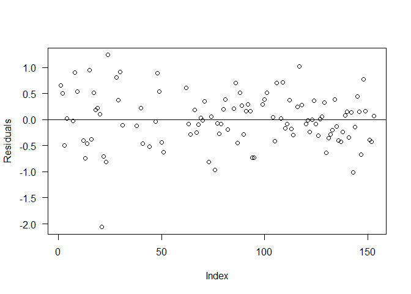

```r
par(las=1, mfrow=c(1,1))
plot(residuals(M2_log), ylab="Residuals")
abline(h=0)
```

If there was serial correlation, we would see either long runs of residuals above or below the line for positive correlation, or greater than normal fluctuations for negative correlation. Unless the effects are strong, they may be difficult to detect. Therefore, it is often better to plot successive residuals.

**Plot of successive residuals $e_i$ against $e_{i+1}$**

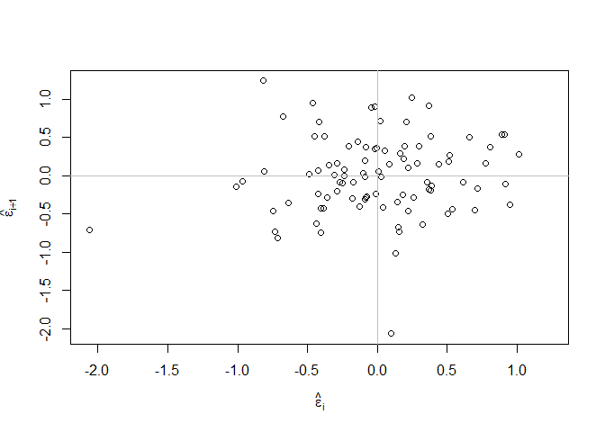

```r
n <- length(residuals(M2_log))
plot(tail(residuals(M2_log),n-1) ~ head(residuals(M2_log),n-1), xlab=expression(hat(epsilon)[i]),ylab=expression(hat(epsilon)[i+1]))
abline(h=0,v=0,col=grey(0.75))
```

No obvious problem with correlated errors is shown. There is an outlier though, which we may try to identify. Is there really only one outlier?

**Regression of $e_{i+1}$ [response] on $e_i$ [explanatory variable]**

```r
summary(lm( tail(residuals(M2_log),n-1) ~ 0 + head(residuals(M2_log),n-1)))
```

```
##
## Call:
## lm(formula = tail(residuals(M2_log), n - 1) ~ 0 + head(residuals(M2_log),
##     n - 1))
##
## Residuals:
##     Min      1Q  Median      3Q     Max
## -2.0727 -0.2895  0.0258  0.3226  1.3259
##
## Coefficients:
##                                Estimate Std. Error t value Pr(>|t|)
## head(residuals(M2_log), n - 1)    0.110      0.105    1.05      0.3
##
## Residual standard error: 0.508 on 91 degrees of freedom
##   (60 observations deleted due to missingness)
## Multiple R-squared:  0.0119, Adjusted R-squared:  0.00107
## F-statistic:  1.1 on 1 and 91 DF,  p-value: 0.297
```

This regression model of successive residuals omits the intercept term, because the mean of the residuals is zero, by definition.

Clearly, there is no substantive correlation (take the square root of R-Squared, which gives 0.10922), also to be shown as follows:

```r
cor(tail(residuals(M2_log),n-1),head(residuals(M2_log),n-1), use="complete.obs")
```

```
## [1] 0.1093
```

**Durbin-Watson test**

```r
library(lmtest)
dwtest(Ozone ~ Solar.R + Wind + Temp, data=na.omit(airquality))
```

```
##
##  Durbin-Watson test
##
## data:  Ozone ~ Solar.R + Wind + Temp
## DW = 1.9, p-value = 0.3
## alternative hypothesis: true autocorrelation is greater than 0
```

```r
dwtest(log(Ozone) ~ Solar.R + Wind + Temp, data=na.omit(airquality))
```

```
##
##  Durbin-Watson test
##
## data:  log(Ozone) ~ Solar.R + Wind + Temp
## DW = 1.8, p-value = 0.1
## alternative hypothesis: true autocorrelation is greater than 0
```

The $p$ value indicates that there is no evidence of correlated errors, but the results should be viewed with skepticism because of the omission of the missing values.

In general, if the errors appear to be correlated, we can use generalized least squares estimation, implemented by the function `gls()`.

# 3 Detecting unusual observations

## 3.1 Leverage points

```r
M1_inf <- influence(M1)
head(M1_inf$hat)
```

```
## Australia   Austria   Belgium   Bolivia    Brazil    Canada
##   0.06771   0.12038   0.08748   0.08947   0.06956   0.15840
```

```r
summary(M1_inf$hat)
```

```
##    Min. 1st Qu.  Median    Mean 3rd Qu.    Max.
##  0.0373  0.0643  0.0750  0.1000  0.0970  0.5315
```

```r
sum(M1_inf$hat)      # sum equals number of regression coeficients
```

```
## [1] 5
```

**High leverage**

```r
k <- 4     # number of predictors
p <- 5     # number of parameters or regression coeficients
n <- length(savings$sr)
which(M1_inf$hat > 2*p/n)
```

```
##       Ireland         Japan United States         Libya
##            21            23            44            49
```

The `hatvalues()` function:

```r
head(hatvalues(M1)) # hat() for a design matrix
```

```
## Australia   Austria   Belgium   Bolivia    Brazil    Canada
##   0.06771   0.12038   0.08748   0.08947   0.06956   0.15840
```

```r
sum(hatvalues(M1))
```

```
## [1] 5
```

**Half-normal plots for leverages**

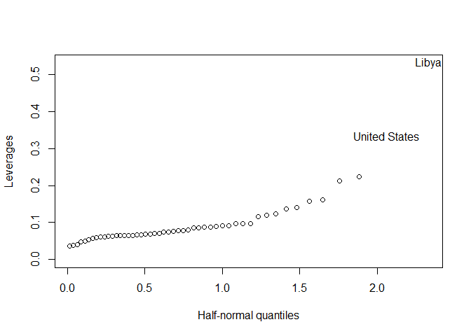

```r
par(mfrow=c(1,1))
countries <- rownames(savings) # stores names of countries
halfnorm(influence(M1)$hat, labs=countries, ylab="Leverages")
```

Plot leverage points against standardized residuals

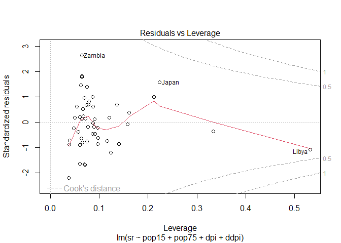

```r
plot(M1, which=5)
```

With the `gglm` package

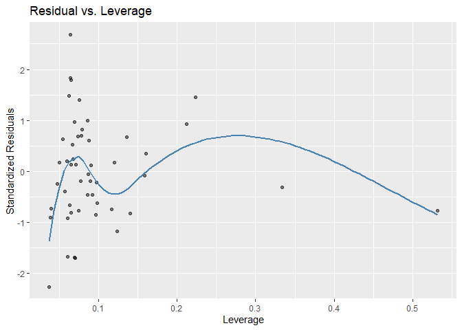

```r
ggplot2::ggplot(data = M1) + stat_resid_leverage()
```

## 3.2 Outliers

**Standardized residuals**

```r
M1_sum$sigma
```

```
## [1] 3.803
```

```r
zresid <- residuals(M1)/(M1_sum$sig) # standardized residuals
head(zresid) # standardized residuals and country names
```

```
## Australia   Austria   Belgium   Bolivia    Brazil    Canada
##   0.22710   0.16209   0.58353  -0.18364   0.93429  -0.08333
```

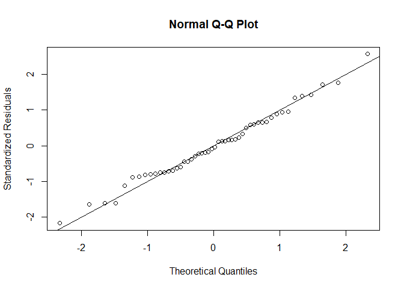

```r
qqnorm(zresid, ylab="Standardized Residuals") # Q-Q plot
abline(0,1) # line 'y = x'
```

**Studentized residuals**

```r
stud <- rstandard(M1) # Studentized residuals and country names
head(stud)
```

```
## Australia   Austria   Belgium   Bolivia    Brazil    Canada
##   0.23520   0.17283   0.61086  -0.19245   0.96859  -0.09084
```

Definition

```r
head(cbind(residuals(M1)/(M1_sum$sigma*sqrt(1 - M1_inf$hat)), stud))
```

```
##                        stud
## Australia  0.23520  0.23520
## Austria    0.17283  0.17283
## Belgium    0.61086  0.61086
## Bolivia   -0.19245 -0.19245
## Brazil     0.96859  0.96859
## Canada    -0.09084 -0.09084
```

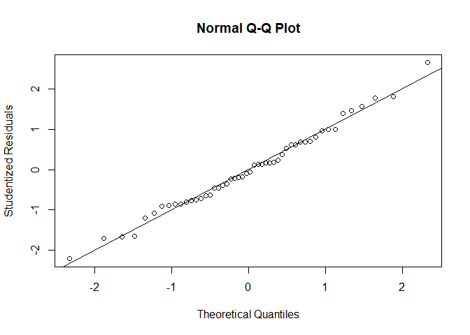

```r
qqnorm(stud, ylab="Studentized Residuals") # Q-Q plot
abline(0,1) # line ’y = x’
```

**Jackknifed Studentized residuals**

```r
jack <- rstudent(M1) # leave-one-out Studentized residuals
```

Definition of leave-one-out Studentized residuals

```r
head(cbind(residuals(M1)/sqrt(M1_inf$sigma^2 * (1-M1_inf$hat)), jack))
```

```
##                        jack
## Australia  0.23272  0.23272
## Austria    0.17096  0.17096
## Belgium    0.60655  0.60655
## Bolivia   -0.19038 -0.19038
## Brazil     0.96791  0.96791
## Canada    -0.08983 -0.08983
```

```r
jack[which.max(abs(jack))]
```

```
## Zambia
##  2.854
```

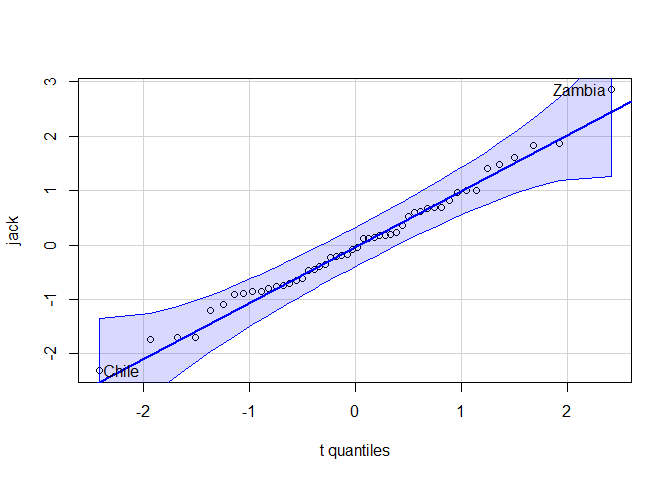

```
## Zambia  Chile
##     46      7
```

```r
library(car)
qqPlot(jack, distribution="t", df=n-k-2)
```

**Is this an outlier?**

$t$ criterium

```r
which(abs(jack) > qt(0.975, n-p-1))
```

```
##  Chile Zambia
##      7     46
```

Dummy criterium

```r
which(abs(jack) > 2)
```

```
##  Chile Zambia
##      7     46
```

Bonferroni criterium

```r
which(abs(jack) > -qt(0.05/(2*n), n-p-1))
```

```
## named integer(0)
```

Bonferroni outlier test

```r
library(car)
outlierTest(M1)
```

```
## No Studentized residuals with Bonferroni p < 0.05
## Largest |rstudent|:
##        rstudent unadjusted p-value Bonferroni p
## Zambia    2.854           0.006567       0.3283
```

## 3.3 Influential observations

**Cook’s distance**

```r
cook <- cooks.distance(M1)
head(cook)
```

```
## Australia   Austria   Belgium   Bolivia    Brazil    Canada
## 0.0008036 0.0008176 0.0071547 0.0007279 0.0140274 0.0003106
```

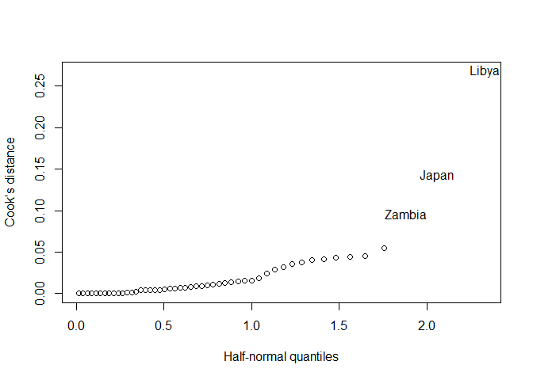

```r
countries <- rownames(savings)
halfnorm(cook, 3, labs=countries, ylab="Cook’s distance")
```

```r
which.max(cook)
```

```
## Libya
##    49
```

There are different opinions regarding what cut-off values to use for spotting highly influential points. Since Cook’s distance is in the metric of an $F$ distribution with $p=k+1$ and $n-p$ degrees of freedom, the median point `qf(0.5,p,n-p)` can be used as a cut-off. Since this value is close to 1 for large $n$, a simple operational guideline of $D_i>1$ has been suggested. For moderate values of $n$, it is suggested to use $D_i > 4/(n-p)$.

Diagnostic lm plotting function

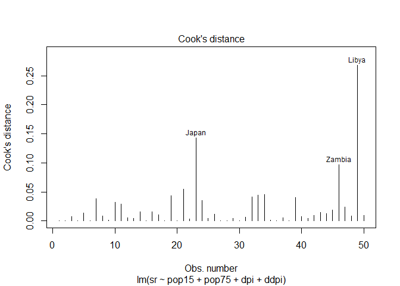

```r
cutoff <- 4/(n-k-1)  # k = number of predictors
plot(M1, which=4, cook.levels=cutoff)
```

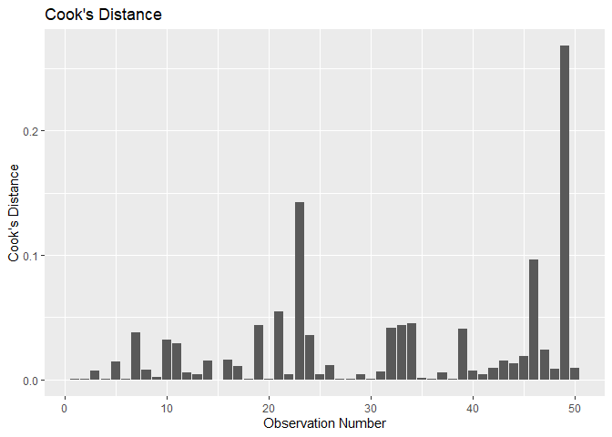

```r
ggplot2::ggplot(data = M1) + stat_cooks_obs()
```

Plot leverage points against Cook’s distance

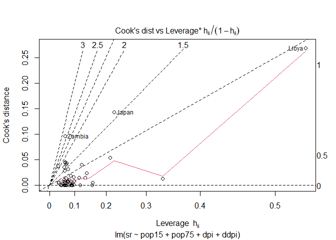

```r
plot(M1, which=6)
```

In the Cook’s distance vs leverage/(1-leverage) plot, contours of standardized residuals `rstandard()` that are equal in magnitude are lines through the origin. The contour lines are labelled with the magnitudes.
$$C_i = \frac{r_i^2}{k+1} \cdot \frac{h_{ii}}{1-h_{ii}}$$
where $C_i$ is the Cook’s distance, $r_i$ the studentized residual and $h_{ii}$ the leverage.

**Influence Plot**

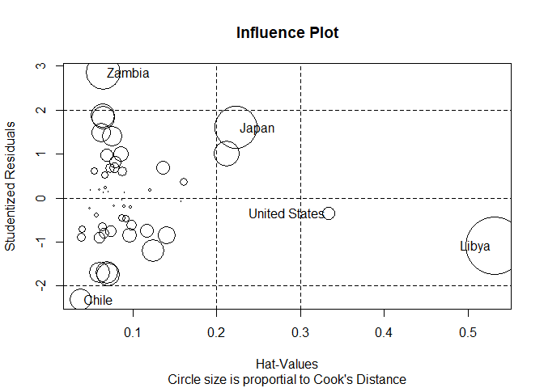

```
##               StudRes     Hat   CookD
## Chile         -2.3134 0.03730 0.03781
## Japan          1.6032 0.22331 0.14282
## United States -0.3546 0.33369 0.01284
## Zambia         2.8536 0.06433 0.09663
## Libya         -1.0893 0.53146 0.26807
```

```r
# library(car)
influencePlot(M1, id=T, main="Influence Plot", sub="Circle size is proportial to Cook's Distance" )
```

**Influence Index Plot**

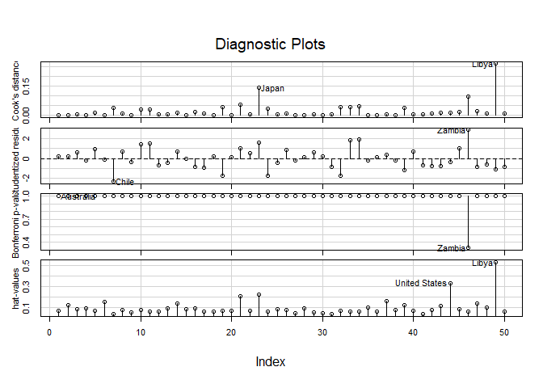

```r
# library(car)
infIndexPlot(M1)
```

**Example**

If we exclude Lybia:

```r
M1_L <- lm(sr ~ pop15 + pop75 + dpi + ddpi, data=savings,
               subset=(cook < max(cook)))
summary(M1_L)
```

```
##
## Call:
## lm(formula = sr ~ pop15 + pop75 + dpi + ddpi, data = savings,
##     subset = (cook < max(cook)))
##
## Residuals:
##    Min     1Q Median     3Q    Max
## -8.070 -2.541 -0.158  2.093  9.373
##
## Coefficients:
##              Estimate Std. Error t value Pr(>|t|)
## (Intercept) 24.524046   8.224026    2.98   0.0047
## pop15       -0.391440   0.157909   -2.48   0.0171
## pop75       -1.280867   1.145182   -1.12   0.2694
## dpi         -0.000319   0.000929   -0.34   0.7331
## ddpi         0.610279   0.268778    2.27   0.0281
##
## Residual standard error: 3.79 on 44 degrees of freedom
## Multiple R-squared:  0.355,  Adjusted R-squared:  0.297
## F-statistic: 6.07 on 4 and 44 DF,  p-value: 0.000562
```

```r
M1_inf <- influence(M1)
head(M1_inf$coef)
```

```
##           (Intercept)      pop15    pop75        dpi       ddpi
## Australia     0.09158 -0.0015256 -0.02905  4.267e-05 -3.157e-05
## Austria      -0.07473  0.0008692  0.04474 -3.456e-05 -1.623e-03
## Belgium      -0.47519  0.0075013  0.13172 -3.255e-05 -1.435e-03
## Bolivia       0.04295 -0.0018574 -0.02467  2.998e-05  8.061e-03
## Brazil        0.66039 -0.0089200 -0.19417  1.118e-04  1.344e-02
## Canada        0.04023 -0.0009873  0.01118 -3.324e-05 -5.255e-04
```

Recall that in the coefficients matrix `M1_inf$coef`, the ith row contains the change in the estimated coefficients which results when the ith case is dropped from the regression.

```r
head(M1_inf$coef[,2])
```

```
##  Australia    Austria    Belgium    Bolivia     Brazil     Canada
## -0.0015256  0.0008692  0.0075013 -0.0018574 -0.0089200 -0.0009873
```

The second column of `M1_inf$coef` is related to the regression coefficient of `pop15`, the first explanatory variable (after the intercept term).

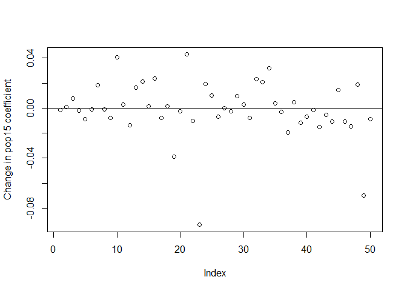

```r
plot(M1_inf$coef[,2], ylab="Change in pop15 coefficient")
abline(h=0)
```

```r
# identify(1:50, M1_inf$coef[,2], countries) # identify plotted points
```

Here, we have plotted the change in the second parameter estimate when a single case is left out. The `identify()` function was used to identify plotted points. The country with the largest change could also be identified with the following command:

```r
which.max(abs(M1_inf$coef[,2]))
```

```
## Japan
##    23
```

The previous plot should be repeated for the other coefficients. In the last plot, `Japan` is an influential observation. We might therefore examine the effect of removing this country from the sample data.

```r
M1_J <- lm(sr ~ pop15 + pop75 + dpi + ddpi, data=savings,
                  subset=(countries != "Japan"))
summary(M1_J)     # linear model estimates without Japan
```

```
##
## Call:
## lm(formula = sr ~ pop15 + pop75 + dpi + ddpi, data = savings,
##     subset = (countries != "Japan"))
##
## Residuals:
##    Min     1Q Median     3Q    Max
## -7.997 -2.592 -0.115  2.032 10.157
##
## Coefficients:
##              Estimate Std. Error t value Pr(>|t|)
## (Intercept) 23.940171   7.783997    3.08   0.0036
## pop15       -0.367901   0.153630   -2.39   0.0210
## pop75       -0.973674   1.155450   -0.84   0.4040
## dpi         -0.000471   0.000919   -0.51   0.6112
## ddpi         0.334749   0.198446    1.69   0.0987
##
## Residual standard error: 3.74 on 44 degrees of freedom
## Multiple R-squared:  0.277,  Adjusted R-squared:  0.211
## F-statistic: 4.21 on 4 and 44 DF,  p-value: 0.00565
```

Compare the results of this model with those of the full model.

# 4 Checking the structure of the model

Diagnostics can also be used to detect deficiencies in the structural part of the model, given by $E(Y) = X\beta$.

Plots of $e_i$ against $\hat{y}_i$ and $x_i$ can also suggest transformations of the variables which might improve the structural form of the model.

We can also make plots of $y$ against each $x_i$.

The drawback to these plots is that the other predictors often affect the relationship between a given predictor and the response.

## 4.1 Added variable plot or partial regression plot

These plots can help isolate the effect of $x_i$ on $y$.

We regress $y$ on all $x$ except $x_i$, and get residuals $\delta$.
$$y = \alpha_0 + \sum_{j\ne i} \alpha_j x_j + \delta$$
Similarly, we regress $x_i$ on all $x$ except $x_i$ and get residuals $\gamma$.
$$x_i = \psi_0 + \sum_{j\ne i} \psi_j x_j + \gamma$$
The added variable plot shows $\delta$ against $\gamma$. Look for non-linearity and outliers and/or influential observations in the plot.

Example: We illustrate using the `savings` dataset as an example again. We construct a partial regression (added variable) plot for `pop15`:

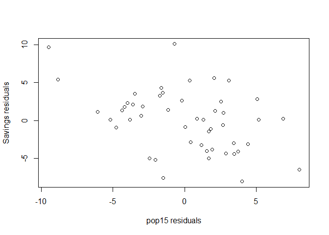

```r
delta <- residuals(lm(sr ~ pop75 + dpi + ddpi, savings))
gamma <- residuals(lm(pop15 ~ pop75 + dpi + ddpi, savings))
plot(gamma, delta, xlab="pop15 residuals", ylab="Savings residuals")
```

The plot shows nothing remarkable. There is no sign of non-linearity or unusual points.

An interesting feature of such plots is revealed by considering the regression line. We compute this for the plot and notice that it is the same as the corresponding coefficient from the full regression:

```r
M1d <- lm(delta ~ gamma)
coef(M1d)
```

```
## (Intercept)       gamma
##   9.908e-17  -4.612e-01
```

```r
coef(M1)
```

```
## (Intercept)       pop15       pop75         dpi        ddpi
##  28.5660865  -0.4611931  -1.6914977  -0.0003369   0.4096949
```

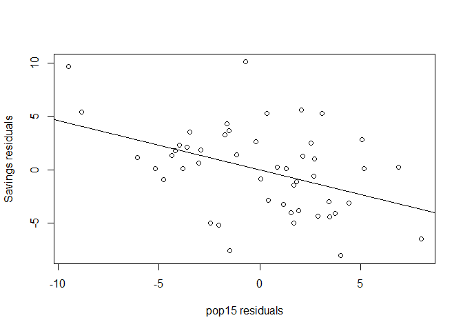

```r
plot(gamma, delta, xlab="pop15 residuals", ylab="Savings residuals")
abline(0, coef(M1)["pop15"])
```

The added variable plot function `avPlots()` in the `car` package does a similar job for all the predictor variables.

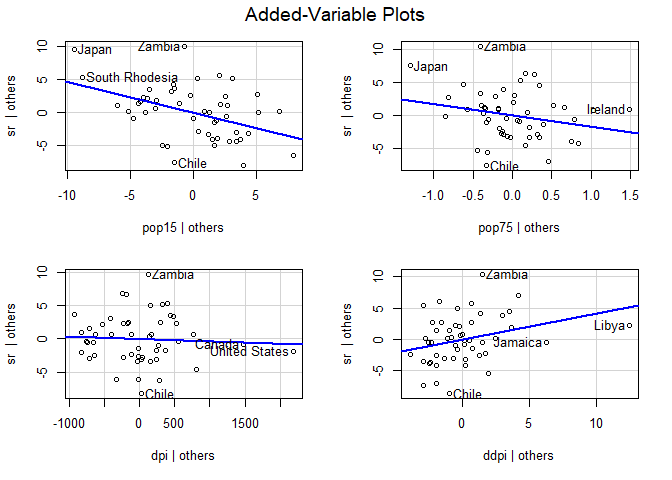

```r
# library(car)
oldpar <- par(mfrow=c(2,2))
avPlots(M1)
```

```r
par(oldpar)
```

## 4.2 Partial residual plot

This is a competitor of the added variable plot.

We know $y = \hat{y} + e$, then we have to
$$y - \sum_{j\ne i} \hat{\beta}_jx_j = \hat{\beta}_i x_i + e$$
We plot $e + \hat{\beta}_i x_i$ against $x_i$. Again, the estimated slope will be $\hat{\beta}_i$. Partial residual plots are better for the detection of linearity, added variable plots are better for the detection of outliers and influential data points.

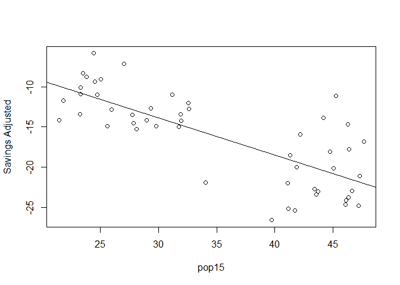

```r
plot(savings$pop15, residuals(M1)+coef(M1)["pop15"]*savings$pop15,
             xlab="pop15", ylab="Savings Adjusted")
abline(0,coef(M1)["pop15"])
```

There is a function that draws the graph directly.

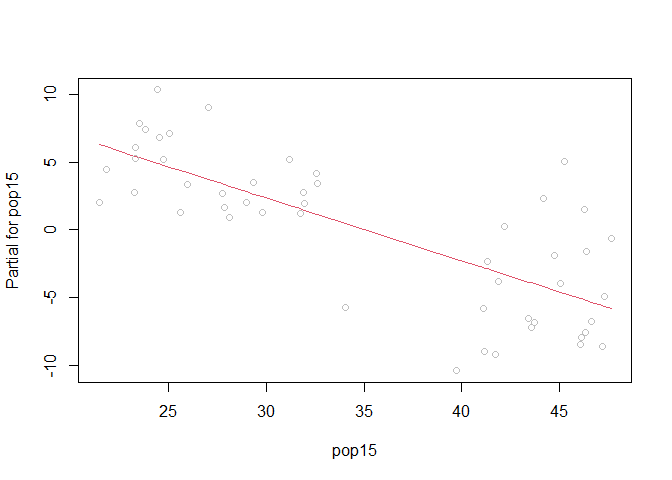

```r
termplot(M1, partial.resid = TRUE, terms = 1)
```

The partial residual plot function `prplot()` from the `faraway` package can be used, which provides the same result.

The functions `crPlot()` or `crPlots()` [component + residual (partial residual) plots] in the `car` package could also be used.

It appears from these plots that there are different relationships in two groups: a group with a low percentage of the population under 15 years (`pop15`), and a group with a high percentage of `pop15`. A division could be made at `pop15 = 35`. We could, therefore, perform two separate analyses, one for each group.

```r
M1_low <- lm(sr ~ pop15+pop75+dpi+ddpi, data=savings, subset=(pop15 < 35))
M1_high <- lm(sr ~ pop15+pop75+dpi+ddpi, data=savings, subset=(pop15 > 35))
```

Try to interpret the results of these analyses whith the summaries, and draw appropriate conclusions. Notice, for example, the different estimates of the residual standard errors in the two groups, and the different R-squared values.

# 5 More diagnostics

The general suite of functions `influence.measures(model)` also contains the functions `dffits(model)`, `dfbeta(model)` and `dfbetas(model)`.